# Project 3: Data Science Skills

Aaron Grzasko, Ahsanul Choudhury, Andrew Carson, Bruce Hao, Daniel Thonn, Dhananjay Kumar, Joseph Elikishvili

October 23, 2016

### Load Data

Now we load the data from the MySQL database. First, a connection is created, then a query is formed. The query is fetched and the results are returned.

```r
library(dbConnect)


#set variables for connecting to MySQL
username = 'data607'

password = 'project3'

dbname = 'ds_skills'

host = 'data607-project3.ce2dfe0qxt5q.us-west-2.rds.amazonaws.com'

myDb = dbConnect(MySQL(), user=username, password=password, dbname=dbname, host=host)


#write query string to pull data from tables in MySQL
qryString = 'SELECT jobs.post_id, role_desc, city, state, keyword_desc

FROM jobs

INNER JOIN locations

ON jobs.loc_id = locations.loc_id

INNER JOIN roles

ON jobs.role_id = roles.role_id

INNER JOIN post_keys

ON jobs.post_id = post_keys.post_id

INNER JOIN  keywords

ON post_keys.key_id = keywords.key_id

;'


#pull query
selectQry = dbSendQuery(myDb, qryString)
results = fetch(selectQry, n = -1)

#display first 10 rows
head(results, n=10)
```

```
##    post_id                      role_desc          city state keyword_desc
## 1      326 senior-software-systems-engine basking-ridge    nj           r
## 2      116 sr-programmer-sr-statistician-  philadelphia    pa           r
## 3        2      consulting-data-scientist     charlotte    nc           r
## 4       34 systems-analyst-staff-eda-data     san-diego    ca           r
## 5       97 quantitative-research-biologis        chelan    wa           r
## 6      433 sr-programmer-sr-statistician-  philadelphia    pa           r
## 7      115          sr-big-data-scientist      bellevue    wa           r
## 8      132 sr-programmer-sr-statistician-  philadelphia    pa           r
## 9       41 talent-management-analyst-data     arlington    va           r
## 10     100          sr-big-data-scientist      bellevue    wa           r
```

### Analysis

Our task is to answer the question: “Which are the most valued data science skills?” The easiest way to answer this is to look at the most frequent keywords in our dataset.

```r
library(ggplot2)
library(tidyr)
library(dplyr)
library(knitr)
library(DT)
library(stringr)

# counts of keywords
keyword_counts<-data.frame(table(results$keyword_desc))
names(keyword_counts)<-c("Keyword","Freq")
head(arrange(keyword_counts,desc(Freq)), n=10)
```

```
##    Keyword Freq
## 1    excel  177
## 2     java  135
## 3      sql  130
## 4   python  123
## 5   hadoop  106
## 6      sas   78
## 7    scala   76
## 8     hive   68
## 9    spark   61
## 10     pig   45
```

We see that Excel tops the list, followed by JAVA, SQL, and Python. Interestingly, R is not near the top.

We add a plot to visualize the result.

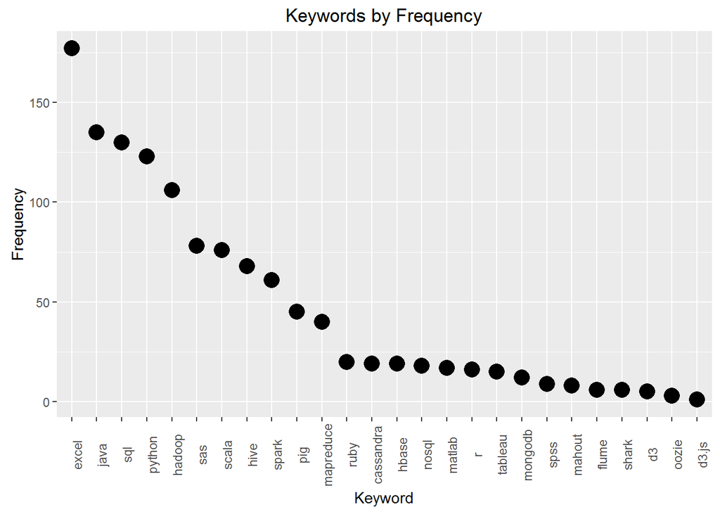

```r
#plot of keyword counts
qplot(data = keyword_counts, x = reorder(Keyword, -Freq), y=Freq, xlab="Keyword", ylab="Frequency", main = "Keywords by Frequency", size=I(5)) +
      theme(text = element_text(),
        axis.text.x = element_text(angle=90, vjust=1))
```

We can see that R is much further down with only 16 counts. Overall, we see programming languages (JAVA, Python), statistical languages (R, SAS), big data languages(Pig, Hive), big data technologies (mapreduce, Hadoop), standard data skills (Excel, SQL), and visualization (Tableau, d3).

Adding nuance, what sorts of roles are we looking at that matched our search query when finding data?

```r
#count of role description
distinct_roles<-distinct(select(results, post_id,role_desc))
distinct_roles<-data.frame(table(distinct_roles$role_desc))
names(distinct_roles)<-c("Role","Freq")
head(arrange(distinct_roles,desc(Freq)), n=10)
```

```
##                              Role Freq
## 1                  data-scientist   30
## 2                              NA   10
## 3  data-scientist-amazon-advertis    7
## 4      machine-learning-scientist    7
## 5  senior-analytics-software-engi    6
## 6                   data-engineer    5
## 7  software-development-engineer-    5
## 8               sr-data-scientist    5
## 9  sr-programmer-sr-statistician-    5
## 10 automotive-title-clerk-billing    4
```

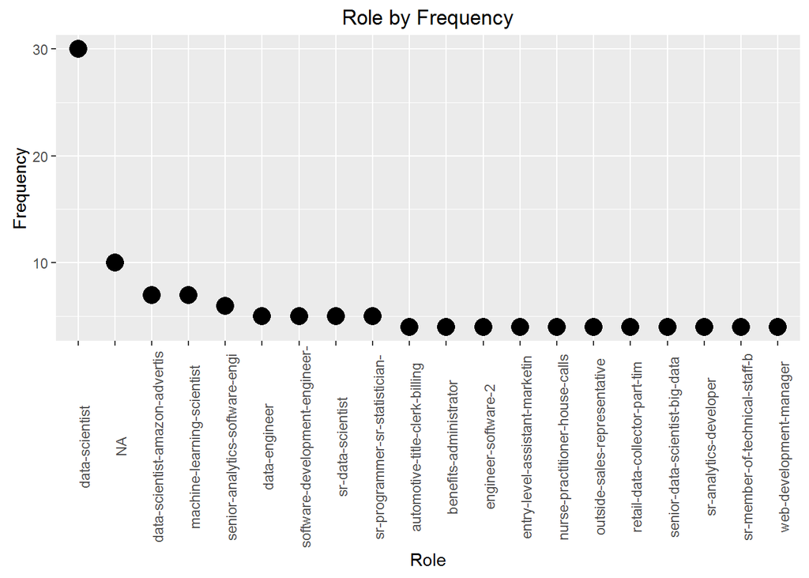

```r
#plot of role description
qplot(data = subset(distinct_roles, Freq>3), x = reorder(Role, -Freq), y=Freq, xlab="Role", ylab="Frequency", main = "Role by Frequency", size=I(5)) +
      theme(text = element_text(),
        axis.text.x = element_text(angle=90, vjust=1))
```

The most frequent is “data-scientist”, which makes sense since this is what we were looking for. We can also see “machine-learning”, “software-engineer”, and “statistician” in the list. Most role descriptions are unique, but could be further grouped if desired.

How do roles and skills align? Take a look at the below table, and sort on the keyword to find which job titles use this skill the most:

```r
#role vs. keyword counts
role_vs_Keyword<-results %>%
  select(role_desc,keyword_desc) %>%
  group_by(role_desc, keyword_desc) %>%
  count(role_desc, keyword_desc) %>%
  spread(role_desc,n)


#keyword vs. role
keyword_vs_role<-results %>%
  select(role_desc,keyword_desc) %>%
  group_by(role_desc, keyword_desc) %>%
  count(role_desc, keyword_desc) %>%
  spread(keyword_desc,n)

#which roles require which skills?
datatable(keyword_vs_role)
```

|  | role_desc | r | cassandra | d3 | d3.js | excel | flume | hadoop | hbase | hive | java | mahout | mapreduce | matlab | mongodb | nosql | oozie | pig | python | ruby | sas | scala | shark | spark | spss | sql | tableau |
| --- | --- | --- | --- | --- | --- | --- | --- | --- | --- | --- | --- | --- | --- | --- | --- | --- | --- | --- | --- | --- | --- | --- | --- | --- | --- | --- | --- |
| 1 | advanced-analytics-data-scient |  |  |  |  | 2 |  |  |  |  | 2 |  | 2 |  |  |  |  |  | 2 |  |  |  |  |  |  | 2 |  |
| 2 | advanced-data-analytics-scient |  |  |  |  | 1 |  | 1 |  | 1 |  |  |  |  |  |  |  |  |  |  |  |  |  |  |  | 1 |  |
| 3 | analytical-chemist |  |  |  |  | 3 |  |  |  |  |  |  |  |  |  |  |  |  |  |  |  | 3 |  |  |  |  |  |
| 4 | applied-mathematician-physicis |  |  |  |  |  |  |  |  |  |  |  |  | 1 |  |  |  |  |  |  |  |  |  |  |  |  |  |
| 5 | applied-scientist |  |  |  |  |  |  |  |  |  | 1 |  |  |  |  |  |  |  | 1 |  |  | 1 |  |  |  |  |  |
| 6 | applied-scientist-machine-lear |  |  |  |  | 1 |  |  |  |  | 2 |  |  |  |  |  |  |  | 2 |  | 1 |  |  |  |  | 1 |  |
| 7 | apps-systems-engineer-4-ab-ini |  |  |  |  |  |  |  |  |  | 1 |  |  |  |  |  |  |  |  |  |  | 1 |  |  |  | 1 |  |
| 8 | associate-data-scientist-san-a |  |  |  |  | 2 |  |  |  |  |  |  |  |  |  |  |  |  |  |  |  |  |  |  |  | 2 |  |
| 9 | associate-director-statistical |  |  |  |  | 1 |  |  |  |  |  |  |  |  |  |  |  |  |  |  | 1 |  |  |  |  |  |  |
| 10 | associate-research-scientist-b |  |  |  |  | 1 |  |  |  |  |  |  |  |  |  |  |  |  |  |  |  |  |  |  |  |  |  |

[output cut: 148 more lines]

Since we are most interested in “data scientists”, let’s look at job titles that match “data-scientist”:

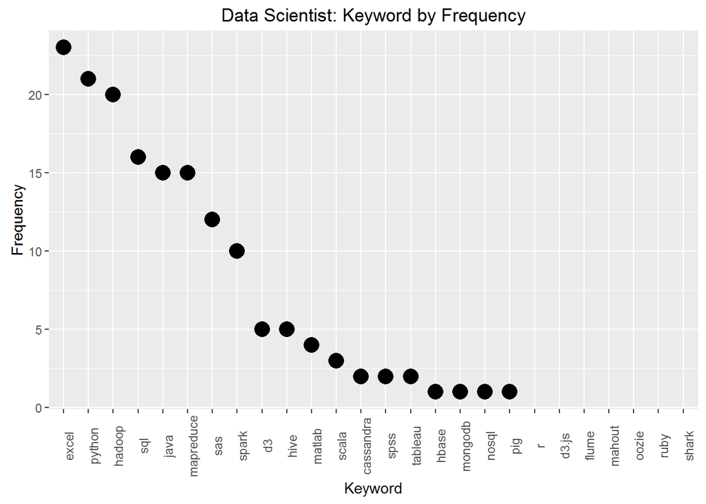

```r
## show top keywords for data-scientist
top_data_scientist<-
  arrange(role_vs_Keyword, desc(`data-scientist`)) %>%
  select(keyword_desc, `data-scientist`)

#plot data-scientist
qplot(data = top_data_scientist, x = reorder(keyword_desc, -`data-scientist`), y=`data-scientist`, xlab="Keyword", ylab="Frequency", main = "Data Scientist: Keyword by Frequency", size=I(5)) +
      theme(text = element_text(),
        axis.text.x = element_text(angle=90, vjust=1))
```

Excel, Python, Hadoop, and SQL are the top four skills. Interestingly, R is not a skill that is associated with the “data-scientist” job title.

What about anything that matches the pattern “data-scien”? This will include all levels of data scientists and other job titles that have this pattern in it.

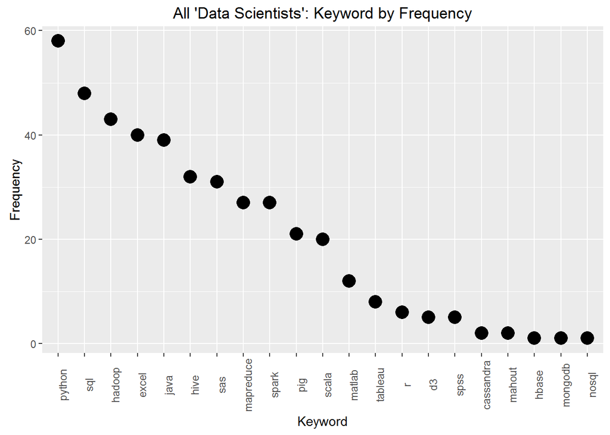

```r
## show top keywords for anything like data scientist
top_data_scientist_all<-
  results %>%
  subset(str_detect(role_desc,"data-scien")) %>%
  select(keyword_desc) %>%
  group_by(keyword_desc) %>%
  count(keyword_desc) %>%
  arrange(desc(n))

#plot data-scientist: all
qplot(data = top_data_scientist_all, x = reorder(keyword_desc, -n), y=n, xlab="Keyword", ylab="Frequency", main = "All 'Data Scientists': Keyword by Frequency", size=I(5)) +
      theme(text = element_text(),
        axis.text.x = element_text(angle=90, vjust=1))
```

It’s the same four skills in a different order: Python, SQL, Hadoop, and Excel. R is now on the chart with 6.

Where are these jobs being offered? We collected the city and state information with these job postings:

```r
#count of city
distinct_city<-distinct(select(results, post_id, city))
distinct_city<-data.frame(table(distinct_city$city))
names(distinct_city)<-c("city","Freq")
head(arrange(distinct_city,desc(Freq)), n=10)
```

```
##            city Freq
## 1       seattle   64
## 2       chicago   10
## 3            NA   10
## 4         plano    9
## 5        boston    7
## 6       redmond    7
## 7   santa-clara    7
## 8          azle    6
## 9      bellevue    6
## 10 philadelphia    6
```

Seattle is the top city at 64, followed by Chicago at 10, and Plano at 9.

What is your city’s favorite data science skill?

```r
#city vs. keyword counts
city_vs_Keyword<-results %>%
  select(city,keyword_desc) %>%
  group_by(city, keyword_desc) %>%
  count(city, keyword_desc) %>%
  spread(city,n)

#keyword vs. city counts
keyword_vs_city<-results %>%
  select(city,keyword_desc) %>%
  group_by(city, keyword_desc) %>%
  count(city, keyword_desc) %>%
  spread(keyword_desc,n)

datatable(keyword_vs_city)
```

|  | city | r | cassandra | d3 | d3.js | excel | flume | hadoop | hbase | hive | java | mahout | mapreduce | matlab | mongodb | nosql | oozie | pig | python | ruby | sas | scala | shark | spark | spss | sql | tableau |
| --- | --- | --- | --- | --- | --- | --- | --- | --- | --- | --- | --- | --- | --- | --- | --- | --- | --- | --- | --- | --- | --- | --- | --- | --- | --- | --- | --- |
| 1 | aiken |  |  |  |  | 2 |  |  |  |  |  |  |  |  |  |  |  |  |  |  |  |  |  |  |  |  |  |
| 2 | alpharetta |  |  |  |  |  |  | 3 |  | 3 | 3 |  | 3 |  |  |  |  | 3 | 3 |  |  |  |  | 3 |  | 3 |  |
| 3 | arlington | 1 |  |  |  | 1 |  |  |  |  | 1 |  |  |  |  |  |  |  | 1 |  |  |  |  |  |  | 1 | 1 |
| 4 | atlanta |  | 1 |  |  | 3 |  | 5 |  | 1 | 2 |  | 3 |  |  | 1 |  | 1 | 2 |  | 3 | 3 |  | 1 |  | 4 | 1 |
| 5 | azle |  |  |  |  |  |  | 6 |  |  |  | 6 |  |  |  |  |  |  |  |  | 6 | 6 |  |  |  | 6 |  |
| 6 | basking-ridge | 1 |  |  | 1 | 1 |  | 2 |  | 2 | 1 |  |  |  |  |  |  |  | 1 |  |  |  |  | 1 |  | 2 |  |
| 7 | bellevue | 2 |  |  |  | 2 |  | 4 |  | 2 | 2 |  |  |  |  |  |  |  |  |  |  |  |  | 2 |  |  | 2 |
| 8 | bloomington |  |  |  |  | 2 |  | 2 |  |  | 2 |  | 2 |  |  |  |  |  | 2 |  | 2 |  |  |  |  | 2 |  |
| 9 | boise |  |  |  |  | 4 |  |  |  |  |  |  |  |  |  |  |  |  |  |  |  |  |  |  |  |  |  |
| 10 | boston | 2 |  |  |  |  |  | 6 |  | 4 | 3 |  | 2 |  |  |  |  | 2 | 2 |  | 2 | 3 |  | 6 |  | 3 |  |

[output cut: 95 more lines]

Finally, we have the state. Washington, California, and Texas have the most job postings. Which skills does your state prefer?

```r
#count of state
distinct_state<-distinct(select(results, post_id, state))
distinct_state<-data.frame(table(distinct_state$state))
names(distinct_state)<-c("state","Freq")
head(arrange(distinct_state,desc(Freq)), n=10)
```

```
##    state Freq
## 1     wa   85
## 2     ca   43
## 3     tx   24
## 4     il   19
## 5     ma   15
## 6     nj   14
## 7     ga   11
## 8     NA   10
## 9     pa    9
## 10    va    9
```

```r
#state vs. keyword counts
state_vs_Keyword<-results %>%
  select(state,keyword_desc) %>%
  group_by(state, keyword_desc) %>%
  count(state, keyword_desc) %>%
  spread(state,n)

#keyword vs. state counts
keyword_vs_state<-results %>%
  select(state,keyword_desc) %>%
  group_by(state, keyword_desc) %>%
  count(state, keyword_desc) %>%
  spread(keyword_desc,n)

datatable(keyword_vs_state)
```

|  | state | r | cassandra | d3 | d3.js | excel | flume | hadoop | hbase | hive | java | mahout | mapreduce | matlab | mongodb | nosql | oozie | pig | python | ruby | sas | scala | shark | spark | spss | sql | tableau |
| --- | --- | --- | --- | --- | --- | --- | --- | --- | --- | --- | --- | --- | --- | --- | --- | --- | --- | --- | --- | --- | --- | --- | --- | --- | --- | --- | --- |
| 1 | al |  |  |  |  | 1 |  |  |  |  |  |  |  |  |  |  |  |  |  |  |  |  |  |  |  |  |  |
| 2 | az |  |  |  |  |  |  | 2 |  | 2 |  |  | 2 |  |  |  |  |  |  |  |  |  |  | 2 |  |  |  |
| 3 | ca | 3 | 4 |  |  | 22 | 4 | 16 | 5 | 12 | 21 | 2 | 5 |  | 2 | 6 | 2 | 8 | 18 |  | 9 | 11 |  | 10 | 2 | 9 | 2 |
| 4 | co |  |  |  |  | 1 | 1 | 1 |  |  | 1 |  |  |  |  |  |  |  | 1 |  | 1 |  |  | 1 |  | 2 |  |
| 5 | ct |  |  |  |  |  |  |  |  |  |  |  |  |  |  |  |  |  |  |  |  |  |  |  |  | 1 |  |
| 6 | dc |  |  |  |  | 4 |  |  |  |  |  |  |  |  |  |  |  |  |  |  |  |  |  |  |  |  |  |
| 7 | fl |  |  |  |  | 7 |  | 1 | 1 | 1 | 1 |  |  |  |  | 1 |  |  |  |  | 2 |  |  |  |  | 1 |  |
| 8 | ga |  | 1 |  |  | 6 |  | 10 | 1 | 5 | 7 |  | 6 |  |  | 1 |  | 4 | 6 |  | 3 | 4 |  | 5 |  | 8 | 1 |
| 9 | ia |  |  |  |  | 4 |  |  |  |  |  |  |  |  |  |  |  |  |  |  |  |  |  |  |  |  |  |
| 10 | id |  |  |  |  | 4 |  |  |  |  |  |  |  |  |  |  |  |  |  |  |  |  |  |  |  |  |  |

[output cut: 23 more lines]

### Conclusion

Our team found that many skills we expected to be popular were: Python, Excel, big data technologies, SQL. The most surprising result is that R is not as popular as we thought it would be or should be. This may be due to the difficulty of extracting “R” from the text of a job description, as we would expect it to be on par with Python in popularity. This would be something that we would investigate for further analysis.